# Binary Classification Model for Credit Card Default Using Python Take 3

### July 7, 2018

Template Credit: Adapted from a template made available by Dr. Jason Brownlee of Machine Learning Mastery. [http://machinelearningmastery.com/]

Dataset Used: Default of Credit Card Clients Data Set

Dataset ML Model: Binary classification with numerical attributes

Dataset Reference: https://archive.ics.uci.edu/ml/datasets/default+of+credit+card+clients

One potential source of performance benchmark: https://www.kaggle.com/uciml/default-of-credit-card-clients-dataset

INTRODUCTION: This dataset contains information on default payments, demographic factors, credit data, history of payment, and bill statements of credit card clients in Taiwan from April 2005 to September 2005.

Previously on the Take No.1 iteration, the baseline performance of the ten algorithms achieved an average accuracy of 74.38%. The group of ensemble algorithms (Bagged CART, Random Forest, Extra Trees, AdaBoost, and Stochastic Gradient Boosting) achieved the top accuracy scores after the first round of modeling. After a series of tuning trials, Stochastic Gradient Boosting turned in the top result using the training data. It achieved an average accuracy of 81.97%. Using the optimized tuning parameter available, the Stochastic Gradient Boosting algorithm processed the validation dataset with an accuracy of 82.91%, which was slightly better than the accuracy of the training data.

For the Take No.2 iteration, we converted the Sex/Gender, Education, and Marital Status attributes into categorical variables and observed the effects on the models. After the conversion, the baseline performance of the ten algorithms achieved an average accuracy of 74.39%. The group of ensemble algorithms (Bagged CART, Random Forest, Extra Trees, AdaBoost, and Stochastic Gradient Boosting) achieved the top accuracy scores after the first round of modeling. After a series of tuning trials, Stochastic Gradient Boosting turned in the top result using the training data. It achieved an average accuracy of 81.96%. Using the optimized tuning parameter available, the Stochastic Gradient Boosting algorithm processed the validation dataset with an accuracy of 82.83%, which was slightly better than the accuracy of the training data.

For the Take No.3 iteration, we will perform the binning operation for the credit limit and age attributes and observe the effects on the models.

CONCLUSION: After the conversion, the baseline performance of the ten algorithms achieved an average accuracy of 74.34%. The group of ensemble algorithms (Bagged CART, Random Forest, Extra Trees, AdaBoost, and Stochastic Gradient Boosting) achieved the top accuracy scores after the first round of modeling. After a series of tuning trials, Stochastic Gradient Boosting turned in the top result using the training data. It achieved an average accuracy of 81.97%. Using the optimized tuning parameter available, the Stochastic Gradient Boosting algorithm processed the validation dataset with an accuracy of 82.75%, which was slightly better than the accuracy of the training data.

For this round of modeling, converting the credit limit and age attributes from ordinal to categorical did not have a noticeable effect on the accuracy of the models.

The purpose of this project is to analyze predictions using various machine learning algorithms and to document the steps using a template. Working through machine learning problems from end-to-end requires a structured modeling approach. Working problems through a project template can also encourage us to think about the problem more critically, to challenge our assumptions, and to get proficient at all parts of a modeling project.

The project aims to touch on the following areas:

- Document a predictive modeling problem end-to-end.
- Explore data cleaning and transformation options
- Explore non-ensemble and ensemble algorithms for baseline model performance
- Explore algorithm tuning techniques for improving model performance

Any predictive modeling machine learning project genrally can be broken down into about six major tasks:

1. Prepare Problem
2. Summarize Data
3. Prepare Data
4. Model and Evaluate Algorithms
5. Improve Accuracy or Results
6. Finalize Model and Present Results

## Section 1 - Prepare Problem

### 1.a) Load ibraries

```python
import numpy as np
import pandas as pd
from matplotlib import pyplot
from pandas import read_csv
from pandas import set_option
from pandas import get_dummies
from pandas.plotting import scatter_matrix
from sklearn.preprocessing import StandardScaler
from sklearn.model_selection import train_test_split
from sklearn.model_selection import KFold
from sklearn.model_selection import cross_val_score
from sklearn.model_selection import GridSearchCV
from sklearn.metrics import classification_report
from sklearn.metrics import confusion_matrix
from sklearn.metrics import accuracy_score
from sklearn.pipeline import Pipeline
from sklearn.linear_model import LogisticRegression
from sklearn.tree import DecisionTreeClassifier
from sklearn.neighbors import KNeighborsClassifier
from sklearn.discriminant_analysis import LinearDiscriminantAnalysis
from sklearn.naive_bayes import GaussianNB
from sklearn.svm import SVC
from sklearn.ensemble import BaggingClassifier
from sklearn.ensemble import RandomForestClassifier
from sklearn.ensemble import ExtraTreesClassifier
from sklearn.ensemble import AdaBoostClassifier
from sklearn.ensemble import GradientBoostingClassifier
from sklearn.externals.joblib import dump
from sklearn.externals.joblib import load
from datetime import datetime
```

### 1.b) Load dataset

```python
startTimeScript = datetime.now()

inputFile = 'default-of-credit-card-clients.csv'
entireDataset = read_csv(inputFile)

# Rename the target variable column to a standard name "targetVar"
entireDataset = entireDataset.rename(columns={'default payment next month': 'targetVar'})

# Drop the Customer ID field as the label column has no relevance in the prediction exercise
entireDataset.drop('CID', axis=1, inplace=True)
```

## Section 2 - Summarize Data

To gain a better understanding of the data that we have on-hand, we will leverage a number of descriptive statistics and data visualization techniques. The plan is to use the results to consider new questions, review assumptions, and validate hypotheses that we can investigate later with specialized models.

### 2.a) Descriptive statistics

```python
# Set up a variable for the total number of attribute columns (totAttr)
totCol = len(entireDataset.columns)
totAttr = totCol-1
# Set up the number of row and columns for visualization display. dispRow * dispCol should be >= totAttr
dispCol = 3
if totAttr % dispCol == 0 :
    dispRow = totAttr // dispCol
else :
    dispRow = (totAttr // dispCol) + 1
```

#### 2.a.i) Peek at the data itself.

```python
set_option('display.width', 100)
print(entireDataset.head(20))
```

```
    LIMIT_BAL  SEX  EDUCATION  MARRIAGE  AGE  PAY_0  PAY_2  PAY_3  PAY_4  PAY_5    ...      \
0       20000    2          2         1   24      2      2     -1     -1     -2    ...
1      120000    2          2         2   26     -1      2      0      0      0    ...
2       90000    2          2         2   34      0      0      0      0      0    ...
3       50000    2          2         1   37      0      0      0      0      0    ...
4       50000    1          2         1   57     -1      0     -1      0      0    ...
5       50000    1          1         2   37      0      0      0      0      0    ...
6      500000    1          1         2   29      0      0      0      0      0    ...
7      100000    2          2         2   23      0     -1     -1      0      0    ...
8      140000    2          3         1   28      0      0      2      0      0    ...
9       20000    1          3         2   35     -2     -2     -2     -2     -1    ...
10     200000    2          3         2   34      0      0      2      0      0    ...
11     260000    2          1         2   51     -1     -1     -1     -1     -1    ...
12     630000    2          2         2   41     -1      0     -1     -1     -1    ...
13      70000    1          2         2   30      1      2      2      0      0    ...
```

[output cut: 52 more lines]

#### 2.a.ii) Dimensions of the dataset.

```python
print(entireDataset.shape)
```

```
(30000, 24)
```

#### 2.a.iii) Types of the attributes.

```python
print(entireDataset.dtypes)
```

```
LIMIT_BAL    int64
SEX          int64
EDUCATION    int64
MARRIAGE     int64
AGE          int64
PAY_0        int64
PAY_2        int64
PAY_3        int64
PAY_4        int64
PAY_5        int64
PAY_6        int64
BILL_AMT1    int64
BILL_AMT2    int64
BILL_AMT3    int64
BILL_AMT4    int64
BILL_AMT5    int64
BILL_AMT6    int64
PAY_AMT1     int64
PAY_AMT2     int64
PAY_AMT3     int64
PAY_AMT4     int64
PAY_AMT5     int64
PAY_AMT6     int64
targetVar    int64
dtype: object
```

#### 2.a.iv) Statistical summary of all attributes.

```python
print(entireDataset.describe())
```

```
            LIMIT_BAL           SEX     EDUCATION      MARRIAGE           AGE         PAY_0  \
count    30000.000000  30000.000000  30000.000000  30000.000000  30000.000000  30000.000000
mean    167484.322667      1.603733      1.853133      1.551867     35.485500     -0.016700
std     129747.661567      0.489129      0.790349      0.521970      9.217904      1.123802
min      10000.000000      1.000000      0.000000      0.000000     21.000000     -2.000000
25%      50000.000000      1.000000      1.000000      1.000000     28.000000     -1.000000
50%     140000.000000      2.000000      2.000000      2.000000     34.000000      0.000000
75%     240000.000000      2.000000      2.000000      2.000000     41.000000      0.000000
max    1000000.000000      2.000000      6.000000      3.000000     79.000000      8.000000

              PAY_2         PAY_3         PAY_4         PAY_5      ...           BILL_AMT4  \
count  30000.000000  30000.000000  30000.000000  30000.000000      ...        30000.000000
mean      -0.133767     -0.166200     -0.220667     -0.266200      ...        43262.948967
std        1.197186      1.196868      1.169139      1.133187      ...        64332.856134
min       -2.000000     -2.000000     -2.000000     -2.000000      ...      -170000.000000
25%       -1.000000     -1.000000     -1.000000     -1.000000      ...         2326.750000
50%        0.000000      0.000000      0.000000      0.000000      ...        19052.000000
75%        0.000000      0.000000      0.000000      0.000000      ...        54506.000000
max        8.000000      8.000000      8.000000      8.000000      ...       891586.000000

           BILL_AMT5      BILL_AMT6       PAY_AMT1      PAY_AMT2      PAY_AMT3       PAY_AMT4  \
count   30000.000000   30000.000000   30000.000000  3.000000e+04   30000.00000   30000.000000
mean    40311.400967   38871.760400    5663.580500  5.921163e+03    5225.68150    4826.076867
std     60797.155770   59554.107537   16563.280354  2.304087e+04   17606.96147   15666.159744
min    -81334.000000 -339603.000000       0.000000  0.000000e+00       0.00000       0.000000
25%      1763.000000    1256.000000    1000.000000  8.330000e+02     390.00000     296.000000
50%     18104.500000   17071.000000    2100.000000  2.009000e+03    1800.00000    1500.000000
75%     50190.500000   49198.250000    5006.000000  5.000000e+03    4505.00000    4013.250000
max    927171.000000  961664.000000  873552.000000  1.684259e+06  896040.00000  621000.000000

            PAY_AMT5       PAY_AMT6     targetVar
count   30000.000000   30000.000000  30000.000000
mean     4799.387633    5215.502567      0.221200
std     15278.305679   17777.465775      0.415062
min         0.000000       0.000000      0.000000
25%       252.500000     117.750000      0.000000
50%      1500.000000    1500.000000      0.000000
75%      4031.500000    4000.000000      0.000000
max    426529.000000  528666.000000      1.000000

[8 rows x 24 columns]
```

#### 2.a.v) Summarize the levels of the class attribute.

```python
print(entireDataset.groupby('targetVar').size())
```

```
targetVar
0    23364
1     6636
dtype: int64
```

#### 2.a.v) Count missing values.

```python
print(entireDataset.isnull().sum())
```

```
LIMIT_BAL    0
SEX          0
EDUCATION    0
MARRIAGE     0
AGE          0
PAY_0        0
PAY_2        0
PAY_3        0
PAY_4        0
PAY_5        0
PAY_6        0
BILL_AMT1    0
BILL_AMT2    0
BILL_AMT3    0
BILL_AMT4    0
BILL_AMT5    0
BILL_AMT6    0
PAY_AMT1     0
PAY_AMT2     0
PAY_AMT3     0
PAY_AMT4     0
PAY_AMT5     0
PAY_AMT6     0
targetVar    0
dtype: int64
```

### 2.b) Data visualizations

##### 2.b.i) Univariate plots to better understand each attribute

```python
# Set figure width to 16 and height to 12 (4:3 aspect ratio)
fig_size = pyplot.rcParams["figure.figsize"]
fig_size[0] = 16
fig_size[1] = 12
pyplot.rcParams["figure.figsize"] = fig_size
```

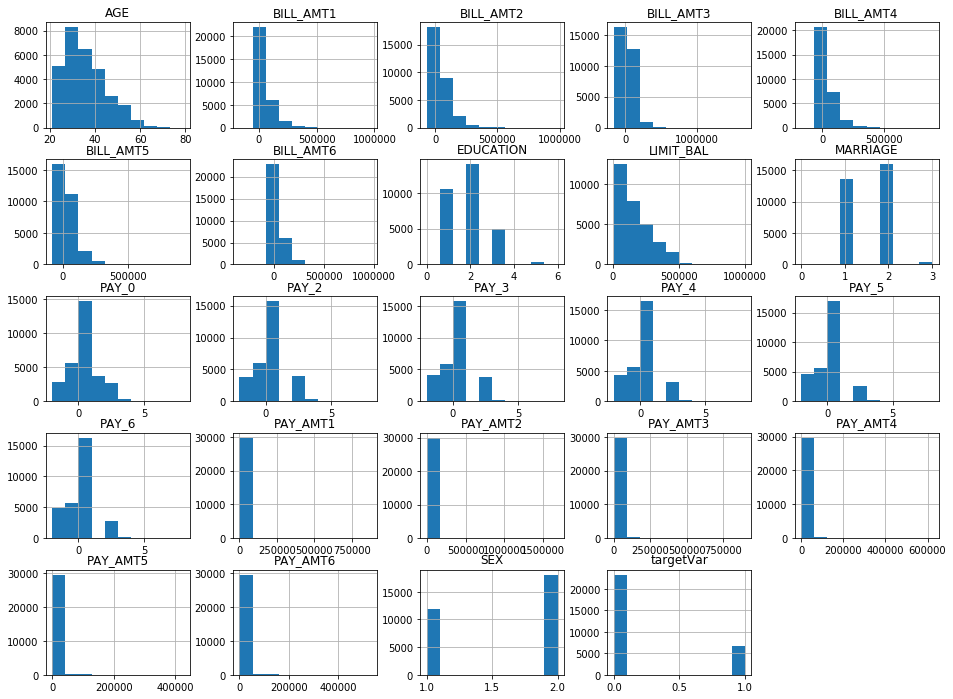

```python
# Histograms for each attribute
entireDataset.hist()
pyplot.show()
```

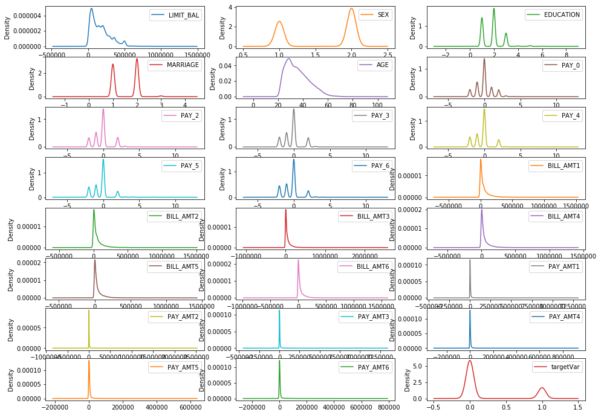

```python
# Density plot for each attribute
entireDataset.plot(kind='density', subplots=True, layout=(dispRow,dispCol), sharex=False)
pyplot.show()
```

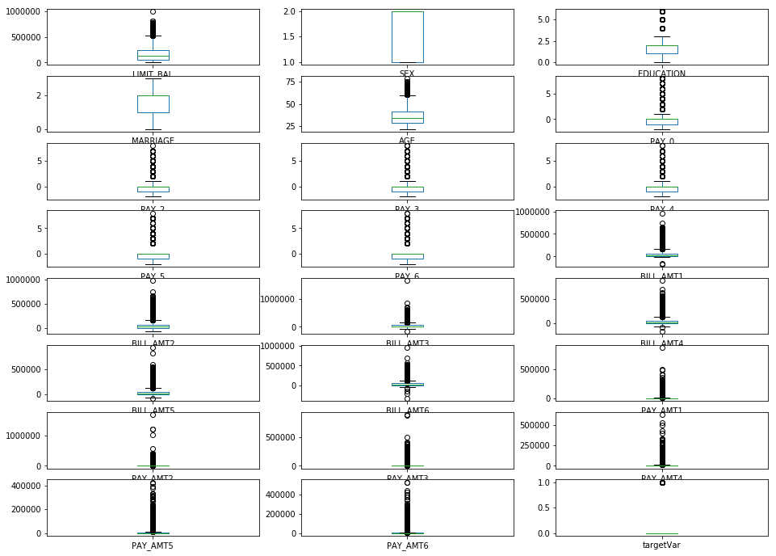

```python
# Box and Whisker plot for each attribute
entireDataset.plot(kind='box', subplots=True, layout=(dispRow,dispCol), sharex=False, sharey=False)
pyplot.show()
```

#### 2.b.ii) Multivariate plots to better understand the relationships between attributes

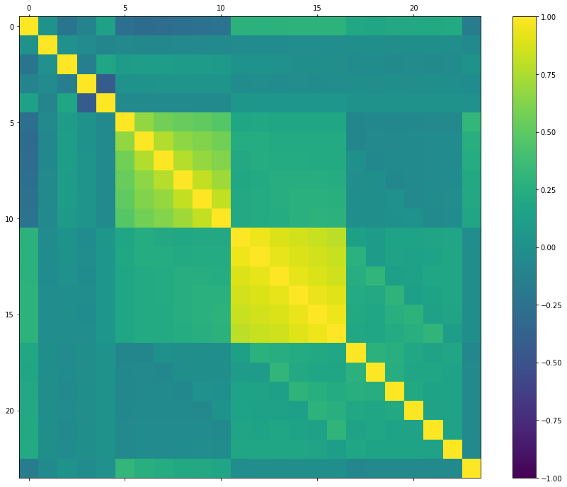

```python
# Correlation matrix
fig = pyplot.figure()
ax = fig.add_subplot(111)
cax = ax.matshow(entireDataset.corr(), vmin=-1, vmax=1)
fig.colorbar(cax)
pyplot.show()
```

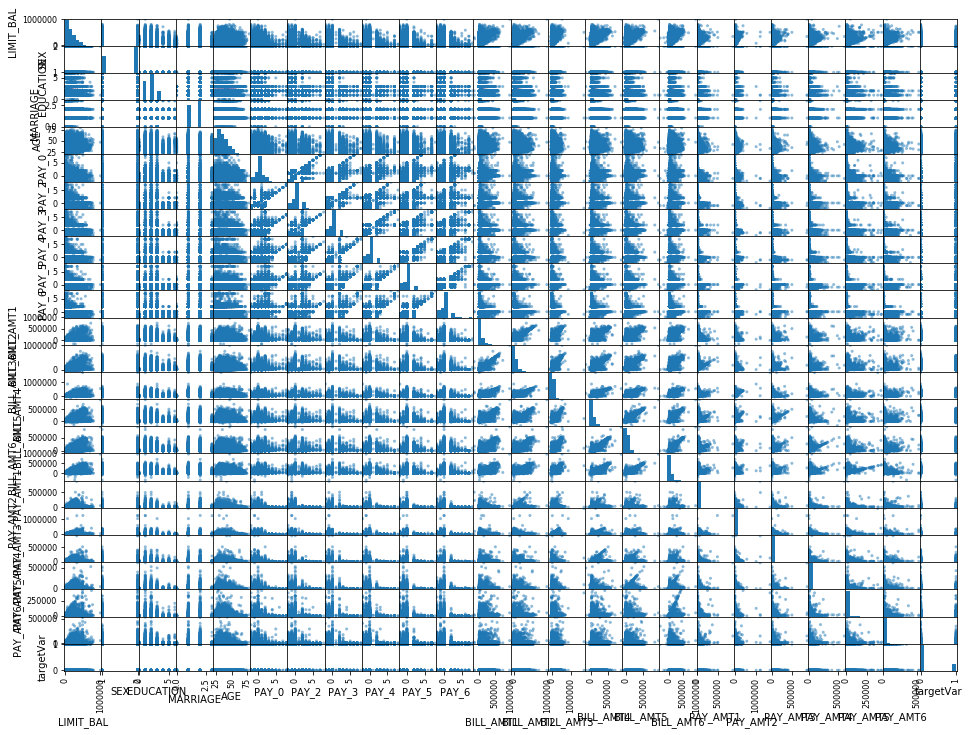

```python
# Scatterplot matrix
scatter_matrix(entireDataset)
pyplot.show()
```

## Section 3 - Prepare Data

Some dataset may require additional preparation activities that will best exposes the structure of the problem and the relationships between the input attributes and the output variable. Some data-prep tasks might include:

- Cleaning data by removing duplicates, marking missing values and even imputing missing values.
- Feature selection where redundant features may be removed.
- Data transforms where attributes are scaled or redistributed in order to best expose the structure of the problem later to learning algorithms.

### 3.a) Data Cleaning

```python
# Correct the invalid values in the Education and Marital Status columns
entireDataset.EDUCATION[entireDataset.EDUCATION == 0] = 4
entireDataset.EDUCATION[entireDataset.EDUCATION == 5] = 4
entireDataset.EDUCATION[entireDataset.EDUCATION == 6] = 4
entireDataset.MARRIAGE[entireDataset.MARRIAGE == 0] = 3
```

### 3.b) Feature Selection

```python
# Not applicable for this iteration of the project.
```

### 3.c) Data Transforms

```python
# Conver the credit limit attribute into bins
credit_bins = [0, 50000, 100000, 200000, 500000, 800000, 1000000]
credit_labels = [1,2,3,4,5,6]
entireDataset['CREDIT_BIN'] = pd.cut(entireDataset['LIMIT_BAL'], bins=credit_bins, labels=credit_labels)

# Drop the Credit Limit field after binning
entireDataset.drop('LIMIT_BAL', axis=1, inplace=True)
```

```python
# Conver the age attribute into bins
age_bins = [20, 30, 40, 50, 60, 70, 80]
age_labels = [1,2,3,4,5,6]
entireDataset['AGE_BIN'] = pd.cut(entireDataset['AGE'], bins=age_bins, labels=age_labels)

# Drop the Age field after binning
entireDataset.drop('AGE', axis=1, inplace=True)
```

```python
# Conver the integer variables to categorical variables as appropriate
entireDataset["SEX"] = entireDataset["SEX"].astype('category')
entireDataset["EDUCATION"] = entireDataset["EDUCATION"].astype('category')
entireDataset["MARRIAGE"] = entireDataset["MARRIAGE"].astype('category')
entireDataset["targetVar"] = entireDataset["targetVar"].astype('category')
print(entireDataset.dtypes)
```

```
SEX           category
EDUCATION     category
MARRIAGE      category
PAY_0            int64
PAY_2            int64
PAY_3            int64
PAY_4            int64
PAY_5            int64
PAY_6            int64
BILL_AMT1        int64
BILL_AMT2        int64
BILL_AMT3        int64
BILL_AMT4        int64
BILL_AMT5        int64
BILL_AMT6        int64
PAY_AMT1         int64
PAY_AMT2         int64
PAY_AMT3         int64
PAY_AMT4         int64
PAY_AMT5         int64
PAY_AMT6         int64
targetVar     category
CREDIT_BIN    category
AGE_BIN       category
dtype: object
```

```python
# Apply the One-Hot-Encoding (Dummy Variables) technique
entireDataset_dummies = get_dummies(entireDataset)
entireDataset_dummies['targetVar'] = entireDataset_dummies['targetVar_1']
entireDataset_dummies.pop('targetVar_0')
entireDataset_dummies.pop('targetVar_1')
print(entireDataset_dummies.dtypes)
```

```
PAY_0           int64
PAY_2           int64
PAY_3           int64
PAY_4           int64
PAY_5           int64
PAY_6           int64
BILL_AMT1       int64
BILL_AMT2       int64
BILL_AMT3       int64
BILL_AMT4       int64
BILL_AMT5       int64
BILL_AMT6       int64
PAY_AMT1        int64
PAY_AMT2        int64
PAY_AMT3        int64
PAY_AMT4        int64
PAY_AMT5        int64
PAY_AMT6        int64
SEX_1           uint8
SEX_2           uint8
EDUCATION_1     uint8
EDUCATION_2     uint8
EDUCATION_3     uint8
EDUCATION_4     uint8
MARRIAGE_1      uint8
MARRIAGE_2      uint8
MARRIAGE_3      uint8
CREDIT_BIN_1    uint8
CREDIT_BIN_2    uint8
CREDIT_BIN_3    uint8
CREDIT_BIN_4    uint8
CREDIT_BIN_5    uint8
CREDIT_BIN_6    uint8
AGE_BIN_1       uint8
AGE_BIN_2       uint8
AGE_BIN_3       uint8
AGE_BIN_4       uint8
AGE_BIN_5       uint8
AGE_BIN_6       uint8
targetVar       uint8
dtype: object
```

```python
print(entireDataset_dummies.head())
```

```
   PAY_0  PAY_2  PAY_3  PAY_4  PAY_5  PAY_6  BILL_AMT1  BILL_AMT2  BILL_AMT3  BILL_AMT4  \
0      2      2     -1     -1     -2     -2       3913       3102        689          0
1     -1      2      0      0      0      2       2682       1725       2682       3272
2      0      0      0      0      0      0      29239      14027      13559      14331
3      0      0      0      0      0      0      46990      48233      49291      28314
4     -1      0     -1      0      0      0       8617       5670      35835      20940

     ...      CREDIT_BIN_4  CREDIT_BIN_5  CREDIT_BIN_6  AGE_BIN_1  AGE_BIN_2  AGE_BIN_3  \
0    ...                 0             0             0          1          0          0
1    ...                 0             0             0          1          0          0
2    ...                 0             0             0          0          1          0
3    ...                 0             0             0          0          1          0
4    ...                 0             0             0          0          0          0

   AGE_BIN_4  AGE_BIN_5  AGE_BIN_6  targetVar
0          0          0          0          1
1          0          0          0          1
2          0          0          0          0
3          0          0          0          0
4          1          0          0          0

[5 rows x 40 columns]
```

### 3.d) Split-out training and validation datasets

We create a training dataset (variable name "training") and a validation dataset (variable name "validation").

```python
seedNum = 777
X_entire = entireDataset_dummies.loc[:, 'PAY_0':'AGE_BIN_6'].values
Y_entire = entireDataset_dummies['targetVar'].values
validation_size = 0.30
X_train, X_validation, Y_train, Y_validation = train_test_split(X_entire, Y_entire, test_size=validation_size, random_state=seedNum)
print("X_entire.shape: {} Y_entire.shape: {}".format(X_entire.shape, Y_entire.shape))
print("X_train.shape: {} Y_train.shape: {}".format(X_train.shape, Y_train.shape))
print("X_validation.shape: {} Y_validation.shape: {}".format(X_validation.shape, Y_validation.shape))
print ('Total time for data handling and visualization:',(datetime.now() - startTimeScript))
```

```
X_entire.shape: (30000, 39) Y_entire.shape: (30000,)
X_train.shape: (21000, 39) Y_train.shape: (21000,)
X_validation.shape: (9000, 39) Y_validation.shape: (9000,)
Total time for data handling and visualization: 0:05:21.012733
```

## 4. Model and Evaluate Algorithms

After the data-prep, we next work on finding a workable model by evaluating a subset of machine learning algorithms that are good at exploiting the structure of the training. The typical evaluation tasks include:

- Defining test options such as cross validation and the evaluation metric to use.
- Spot checking a suite of linear and nonlinear machine learning algorithms.
- Comparing the estimated accuracy of algorithms.

For this project, we will evaluate one linear, four non-linear and five ensemble algorithms:

Linear Algorithm: Logistic Regression

Non-Linear Algorithms: Decision Trees (CART), Naive Bayes, k-Nearest Neighbors, and Support Vector Machine

Ensemble Algorithms: Bagged CART, Random Forest, Extra Trees, AdaBoost, and Stochastic Gradient Boosting

The random number seed is reset before each run to ensure that the evaluation of each algorithm is performed using the same data splits. It ensures the results are directly comparable.

### 4.a) Set test options and evaluation metric

```python
# Run algorithms using 10-fold cross validation
num_folds = 10
scoring = 'accuracy'
```

```python
# Set up Algorithms Spot-Checking Array
models = []
models.append(('LR', LogisticRegression(random_state=seedNum)))
models.append(('CART', DecisionTreeClassifier(random_state=seedNum)))
models.append(('NB', GaussianNB()))
models.append(('KNN', KNeighborsClassifier()))
models.append(('SVM', SVC(random_state=seedNum)))
models.append(('BT', BaggingClassifier(random_state=seedNum)))
models.append(('RF', RandomForestClassifier(random_state=seedNum)))
models.append(('ET', ExtraTreesClassifier(random_state=seedNum)))
models.append(('AB', AdaBoostClassifier(random_state=seedNum)))
models.append(('GBM', GradientBoostingClassifier(random_state=seedNum)))
results = []
names = []
metrics = []
```

```python
# Generate model in turn
for name, model in models:
	startTimeModule = datetime.now()
	kfold = KFold(n_splits=num_folds, random_state=seedNum)
	cv_results = cross_val_score(model, X_train, Y_train, cv=kfold, scoring=scoring)
	results.append(cv_results)
	names.append(name)
	metrics.append(cv_results.mean())
	msg = "%s: %f (%f)" % (name, cv_results.mean(), cv_results.std())
	print(msg)
	print ('Model training time:',(datetime.now() - startTimeModule))
print ('Average metrics (accuracy %) from all models:',np.mean(metrics))
```

```
LR: 0.780190 (0.006231)
Model training time: 0:00:04.384787
CART: 0.722476 (0.012112)
Model training time: 0:00:04.185901
NB: 0.371000 (0.010170)
Model training time: 0:00:00.290117
KNN: 0.759000 (0.006702)
Model training time: 0:00:04.433983
SVM: 0.780238 (0.006279)
Model training time: 0:26:39.735891
BT: 0.802381 (0.005730)
Model training time: 0:00:28.508347
RF: 0.800429 (0.005077)
Model training time: 0:00:04.219927
ET: 0.786381 (0.008452)
Model training time: 0:00:02.540037
AB: 0.813762 (0.004614)
Model training time: 0:00:16.733812
GBM: 0.818857 (0.005743)
Model training time: 0:00:35.782429
Average metrics (accuracy %) from all models: 0.7434714285714286
```

### 4.b) Spot-checking baseline algorithms

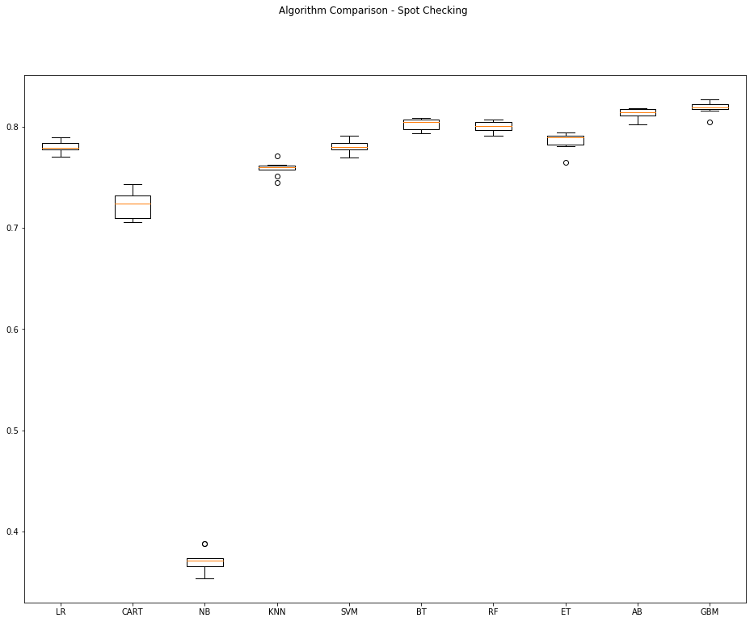

```python
fig = pyplot.figure()
fig.suptitle('Algorithm Comparison - Spot Checking')
ax = fig.add_subplot(111)
pyplot.boxplot(results)
ax.set_xticklabels(names)
pyplot.show()
```

## Section 5 - Improve Accuracy

After we achieve a short list of machine learning algorithms with good level of accuracy, we can leverage ways to improve the accuracy of the models.

### 5.a) Algorithm Tuning

```python
# Set up the comparison array
results = []
names = []
```

```python
# Tuning algorithm #1 - Random Forest
startTimeModule = datetime.now()
paramGrid1 = dict(n_estimators=np.array([200,300,500,700,900]))
model1 = RandomForestClassifier(random_state=seedNum)
kfold = KFold(n_splits=num_folds, random_state=seedNum)
grid1 = GridSearchCV(estimator=model1, param_grid=paramGrid1, scoring=scoring, cv=kfold)
grid_result1 = grid1.fit(X_train, Y_train)

print("Best: %f using %s" % (grid_result1.best_score_, grid_result1.best_params_))
results.append(grid_result1.cv_results_['mean_test_score'])
names.append('RF')
means = grid_result1.cv_results_['mean_test_score']
stds = grid_result1.cv_results_['std_test_score']
params = grid_result1.cv_results_['params']
for mean, stdev, param in zip(means, stds, params):
    print("%f (%f) with: %r" % (mean, stdev, param))
print ('Model training time:',(datetime.now() - startTimeModule))
```

```
Best: 0.814048 using {'n_estimators': 700}
0.811762 (0.005545) with: {'n_estimators': 200}
0.812524 (0.005217) with: {'n_estimators': 300}
0.813238 (0.005137) with: {'n_estimators': 500}
0.814048 (0.004519) with: {'n_estimators': 700}
0.813714 (0.004601) with: {'n_estimators': 900}
Model training time: 0:21:30.289480
```

```python
# Tuning algorithm #2 - AdaBoost
startTimeModule = datetime.now()
paramGrid2 = dict(n_estimators=np.array([100,200,300,400,500]))
model2 = AdaBoostClassifier(random_state=seedNum)
kfold = KFold(n_splits=num_folds, random_state=seedNum)
grid2 = GridSearchCV(estimator=model2, param_grid=paramGrid2, scoring=scoring, cv=kfold)
grid_result2 = grid2.fit(X_train, Y_train)

print("Best: %f using %s" % (grid_result2.best_score_, grid_result2.best_params_))
results.append(grid_result2.cv_results_['mean_test_score'])
names.append('AB')
means = grid_result2.cv_results_['mean_test_score']
stds = grid_result2.cv_results_['std_test_score']
params = grid_result2.cv_results_['params']
for mean, stdev, param in zip(means, stds, params):
    print("%f (%f) with: %r" % (mean, stdev, param))
print ('Model training time:',(datetime.now() - startTimeModule))
```

```
Best: 0.814905 using {'n_estimators': 200}
0.814381 (0.004865) with: {'n_estimators': 100}
0.814905 (0.005675) with: {'n_estimators': 200}
0.814857 (0.005690) with: {'n_estimators': 300}
0.814381 (0.005581) with: {'n_estimators': 400}
0.814286 (0.006102) with: {'n_estimators': 500}
Model training time: 0:11:14.077906
```

```python
# Tuning algorithm #3 - Stochastic Gradient Boosting
startTimeModule = datetime.now()
paramGrid3 = dict(n_estimators=np.array([25,50,100,150,200]))
model3 = GradientBoostingClassifier(random_state=seedNum)
kfold = KFold(n_splits=num_folds, random_state=seedNum)
grid3 = GridSearchCV(estimator=model3, param_grid=paramGrid3, scoring=scoring, cv=kfold)
grid_result3 = grid3.fit(X_train, Y_train)

print("Best: %f using %s" % (grid_result3.best_score_, grid_result3.best_params_))
results.append(grid_result3.cv_results_['mean_test_score'])
names.append('GBM')
means = grid_result3.cv_results_['mean_test_score']
stds = grid_result3.cv_results_['std_test_score']
params = grid_result3.cv_results_['params']
for mean, stdev, param in zip(means, stds, params):
    print("%f (%f) with: %r" % (mean, stdev, param))
print ('Model training time:',(datetime.now() - startTimeModule))
```

```
Best: 0.819714 using {'n_estimators': 50}
0.818381 (0.006523) with: {'n_estimators': 25}
0.819714 (0.006062) with: {'n_estimators': 50}
0.818857 (0.005743) with: {'n_estimators': 100}
0.817762 (0.005825) with: {'n_estimators': 150}
0.817190 (0.005976) with: {'n_estimators': 200}
Model training time: 0:03:47.702354
```

```python
# Tuning algorithm #4 - Bagged CART
startTimeModule = datetime.now()
paramGrid4 = dict(n_estimators=np.array([50,100,150,200,250]))
model4 = BaggingClassifier(random_state=seedNum)
kfold = KFold(n_splits=num_folds, random_state=seedNum)
grid4 = GridSearchCV(estimator=model4, param_grid=paramGrid4, scoring=scoring, cv=kfold)
grid_result4 = grid4.fit(X_train, Y_train)

print("Best: %f using %s" % (grid_result4.best_score_, grid_result4.best_params_))
results.append(grid_result4.cv_results_['mean_test_score'])
names.append('BT')
means = grid_result4.cv_results_['mean_test_score']
stds = grid_result4.cv_results_['std_test_score']
params = grid_result4.cv_results_['params']
for mean, stdev, param in zip(means, stds, params):
    print("%f (%f) with: %r" % (mean, stdev, param))
print ('Model training time:',(datetime.now() - startTimeModule))
```

```
Best: 0.811762 using {'n_estimators': 250}
0.809429 (0.004348) with: {'n_estimators': 50}
0.810286 (0.004064) with: {'n_estimators': 100}
0.810619 (0.004493) with: {'n_estimators': 150}
0.811714 (0.003945) with: {'n_estimators': 200}
0.811762 (0.004152) with: {'n_estimators': 250}
Model training time: 0:35:09.315755
```

```python
# Tuning algorithm #5 - Extra Trees
startTimeModule = datetime.now()
paramGrid5 = dict(n_estimators=np.array([100,150,200,250,300]))
model5 = ExtraTreesClassifier(random_state=seedNum)
kfold = KFold(n_splits=num_folds, random_state=seedNum)
grid5 = GridSearchCV(estimator=model5, param_grid=paramGrid5, scoring=scoring, cv=kfold)
grid_result5 = grid5.fit(X_train, Y_train)

print("Best: %f using %s" % (grid_result5.best_score_, grid_result5.best_params_))
results.append(grid_result5.cv_results_['mean_test_score'])
names.append('ET')
means = grid_result5.cv_results_['mean_test_score']
stds = grid_result5.cv_results_['std_test_score']
params = grid_result5.cv_results_['params']
for mean, stdev, param in zip(means, stds, params):
    print("%f (%f) with: %r" % (mean, stdev, param))
print ('Model training time:',(datetime.now() - startTimeModule))
```

```
Best: 0.799048 using {'n_estimators': 100}
0.799048 (0.006124) with: {'n_estimators': 100}
0.798048 (0.005999) with: {'n_estimators': 150}
0.796857 (0.006711) with: {'n_estimators': 200}
0.797857 (0.006671) with: {'n_estimators': 250}
0.797238 (0.006851) with: {'n_estimators': 300}
Model training time: 0:05:09.498993
```

### 5.b) Compare Algorithms After Tuning

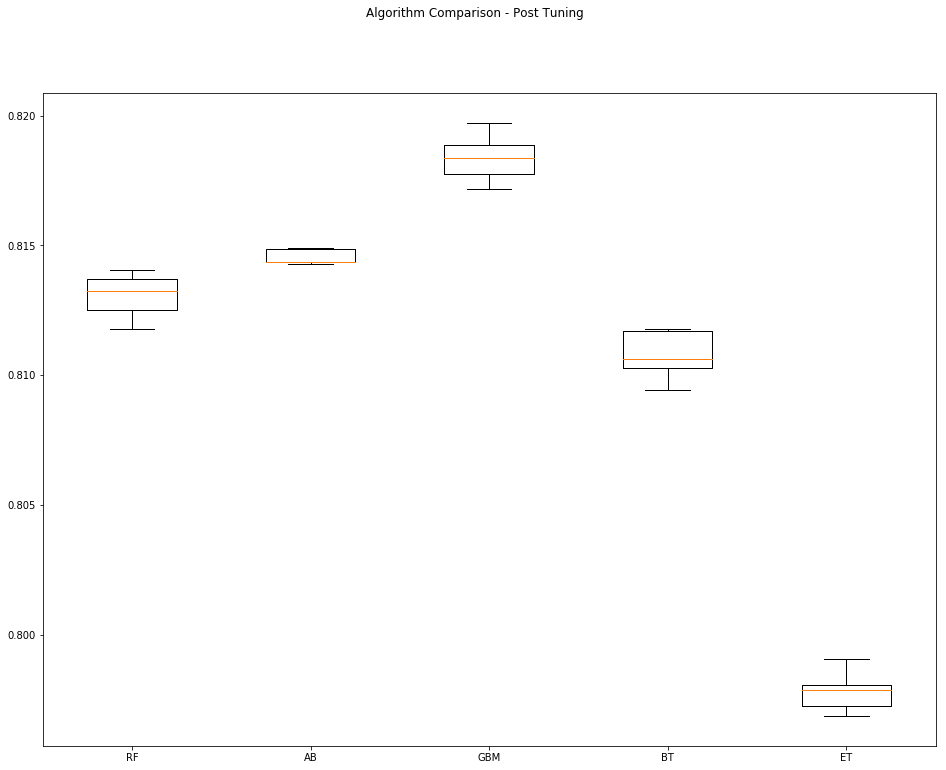

```python
fig = pyplot.figure()
fig.suptitle('Algorithm Comparison - Post Tuning')
ax = fig.add_subplot(111)
pyplot.boxplot(results)
ax.set_xticklabels(names)
pyplot.show()
```

## Section 6 - Finalize Model

Once we have narrow down to a model that we believe can make accurate predictions on unseen data, we are ready to finalize it. Finalizing a model may involve sub-tasks such as:

- Using an optimal model tuned to make predictions on unseen data.
- Creating a standalone model using the tuned parameters
- Saving an optimal model to file for later use.

### 6.a) Predictions on validation dataset

```python
model = GradientBoostingClassifier(n_estimators=50, random_state=seedNum)
model.fit(X_train, Y_train)
predictions = model.predict(X_validation)
print(accuracy_score(Y_validation, predictions))
print(confusion_matrix(Y_validation, predictions))
print(classification_report(Y_validation, predictions))
```

```
0.8275555555555556
[[6714  319]
 [1233  734]]
             precision    recall  f1-score   support

          0       0.84      0.95      0.90      7033
          1       0.70      0.37      0.49      1967

avg / total       0.81      0.83      0.81      9000
```

### 6.b) Create standalone model on entire training dataset

```python
startTimeModule = datetime.now()
finalModel = GradientBoostingClassifier(n_estimators=50, random_state=seedNum)
finalModel.fit(X_entire, Y_entire)
print ('Model training time:',(datetime.now() - startTimeModule))
```

```
Model training time: 0:00:02.450574
```

### 6.c) Save model for later use

```python
# modelName = 'finalModel_BinaryClass.sav'
# dump(finalModel, modelName)

print ('Total time for the script:',(datetime.now() - startTimeScript))
```

```
Total time for the script: 1:50:38.088335
```